# EXPLORING MAPS IN R

Parasite epidemiology in Dosso Region, Niger

Jacqueline Maasch

7/16/2019

Load libraries: library(maps) library(mapdata) library(mapproj) library(spData) library(grid) library(sp) library(dplyr) library(ggplot2) library(ggmap) library(ggthemes) library(cowplot)

Access level 2 administrative regions sp file at: https://gadm.org/download_country_v3.html Data hosting provided by the Center for Spatial Sciences at the University of California, Davis.

Advice on usage available at: http://rforbiochemists.blogspot.com/2017/04/three-maps-of-namibia.html

Explore administrative regions in base R.

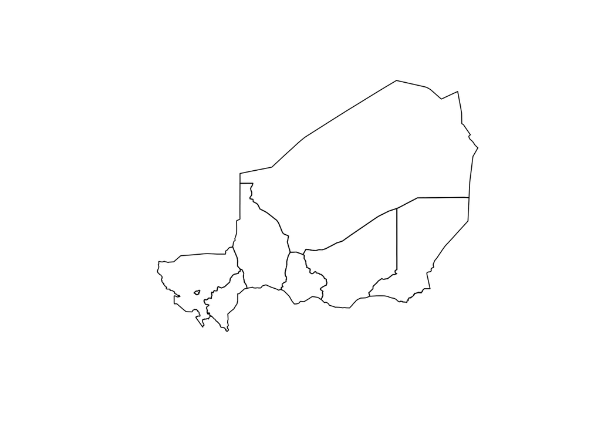

```r
nigerRegions <- readRDS("/Users/razel/Dropbox/Niger parasite epi/Data/Map/gadm36_NER_1_sp.rds")

plot(nigerRegions)
```

Explore departmental boundaries in base R.

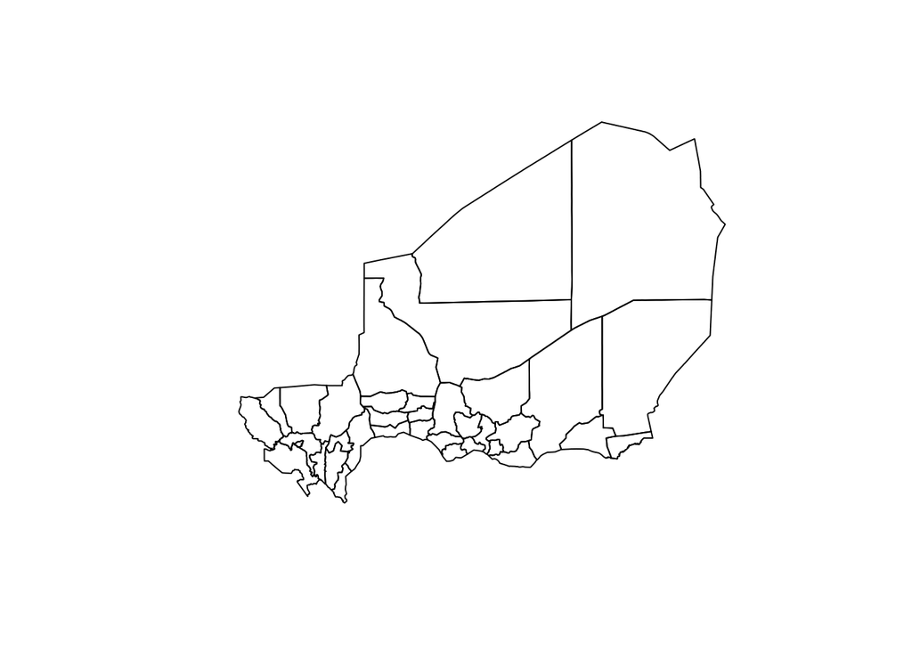

```r
nigerDept <- readRDS("/Users/razel/Dropbox/Niger parasite epi/Data/Map/gadm36_NER_2_sp.rds")

plot(nigerDept)
```

Explore aesthetics in base R.

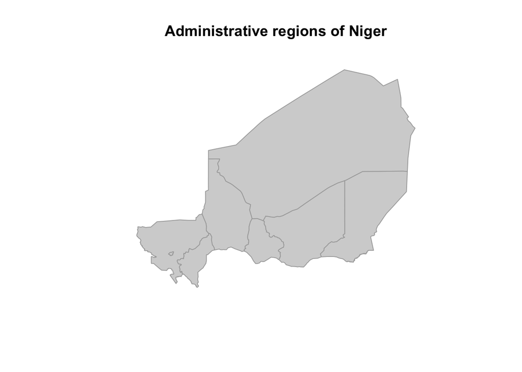

```r
plot(nigerRegions, col = 'lightgrey', border = 'darkgrey')
title(main = "Administrative regions of Niger")
```

Label villages:

BABA DEY: 12.851563 2.775743 GOBERI PEULH: 12.9819084 2.8755067 GUILLARE PEULH: 13.1197411 2.8491551 LISSORE: 12.7657579 2.8753615 MOUNBEINA FANDOGA: 13.4575975 2.9316658 POULLO: 13.0840501 2.7768802 SETTI I: 13.0993277 2.9772676 TOMBO: 12.9739898 2.6858407 WERE DJATAME PEUL: 12.8960019 2.9372924

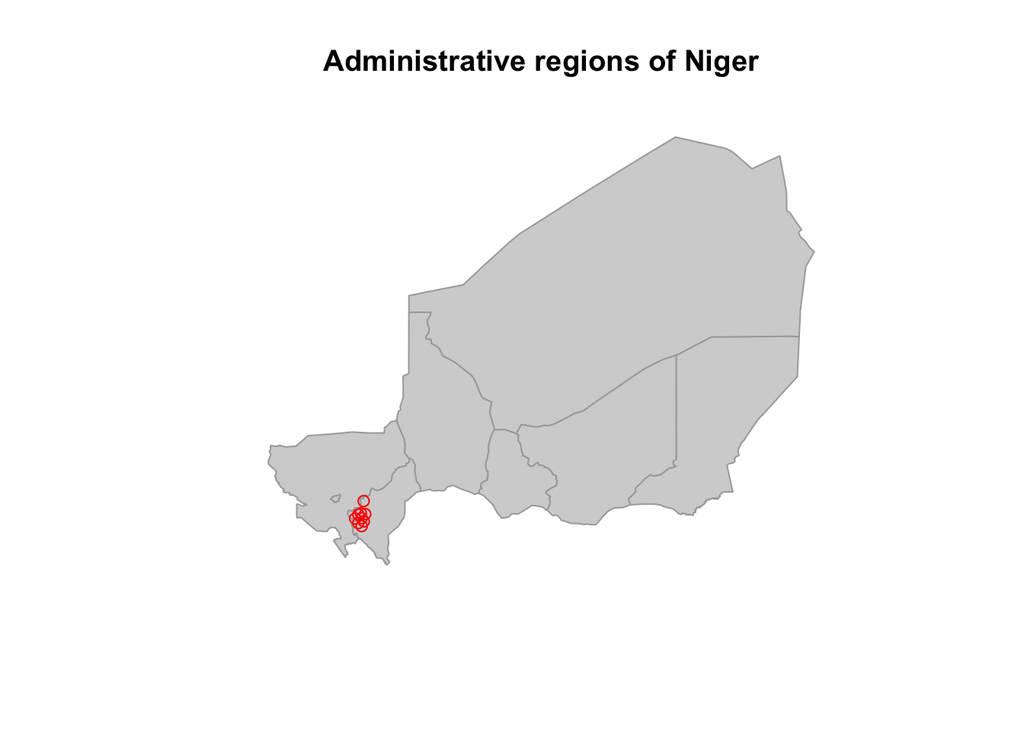

```r
plot(nigerRegions, col = 'lightgrey', border = 'darkgrey')
title(main = "Administrative regions of Niger")
points(2.775743, 12.851563, col = "red") #BABA DEY
points(2.8755067, 12.9819084, col = "red") #GOBERI PEULH
points(2.8491551, 13.1197411, col = "red") #GUILLARE PEULH
points(2.8753615, 12.7657579, col = "red") #LISSORE
points(2.9316658, 13.4575975, col = "red") #MOUNBEINA FANDOGA
points(2.7768802, 13.0840501, col = "red") #POULLO
points(2.9772676, 13.0993277, col = "red") #SETTI I
points(2.6858407, 12.9739898, col = "red") #TOMBO
points(2.9372924, 12.8960019, col = "red") #WERE DJATAME PEUL
```

```r
#text(longitude, latitude, "Name")
```

Explore administrative regions in ggplot2. For ggthemes: https://yutannihilation.github.io/allYourFigureAreBelongToUs/ggthemes/

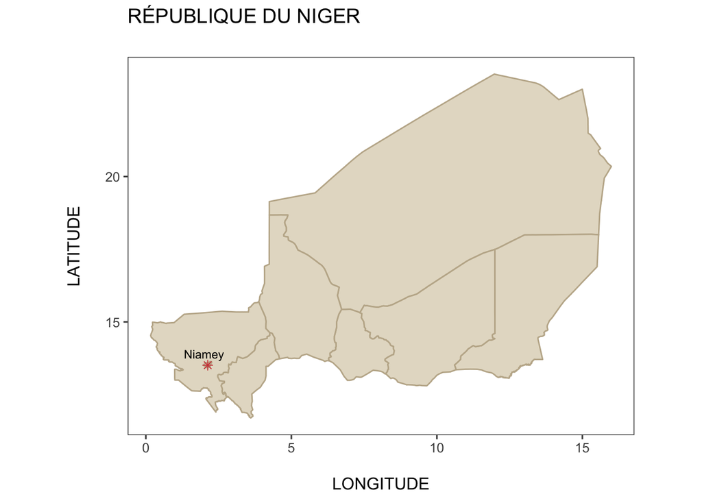

```r
nigerMapRegions <- ggplot() +
  geom_polygon(data = nigerRegions,   # geom_polygon draw shape fill
               aes(x= long,     # longitude
                   y= lat,      # latitude
                   group = group),
               colour = "#C1B398",
               fill = "#E5DDCB") +
  theme_few() +
  coord_fixed(ratio = 1, xlim = NULL, ylim = NULL, expand = TRUE, clip = "on") +
  labs(title = "RÉPUBLIQUE DU NIGER\n",
       x = "\nLONGITUDE",
       y = "LATITUDE\n") +
  annotate("point", x = 2.1254, y = 13.5116, size = 2, colour = "#CF4647", shape = 8) + #Niamey
  annotate("text", x = 2, y = 13.9, label = "Niamey", size = 3) #Niamey
nigerMapRegions
```

Zoom to view Dosso region. https://stackoverflow.com/questions/18323832/plot-small-region-of-a-large-polygon-map-in-ggplot2

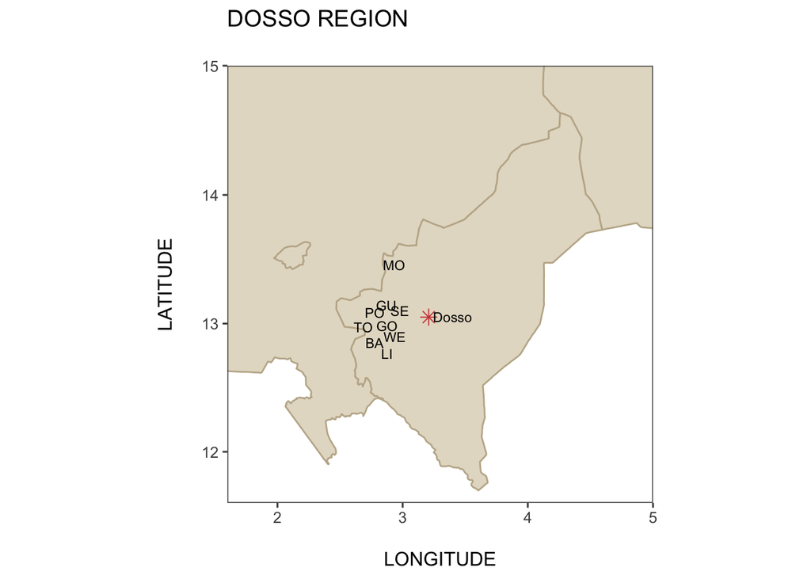

```r
nigerDosso <- ggplot() +
  geom_polygon(data = nigerRegions, #geom_polygon draw shape fill
               aes(x= long, #longitude
                   y= lat, #latitude
                   group = group),
               fill = "#E5DDCB",
               colour = "#C1B398") +
  theme_few() +
  labs(title = "DOSSO REGION\n",
       x = "\nLONGITUDE",
       y = "LATITUDE\n") +
  coord_fixed(ratio = 1, xlim = NULL, ylim = NULL, expand = TRUE, clip = "on") +
  coord_map(xlim = c(1.6, 5), ylim = c(11.6, 15)) +
  annotate("text", x = 2.775743, y = 12.851563, label = "BA", size = 3) + #BABA DEY
  annotate("text", x = 2.8755067, y = 12.9819084, label = "GO", size = 3) + #GOBERI PEULH
  annotate("text", x = 2.87, y = 13.14, label = "GU", size = 3) + #GUILLARE PEULH, COORDS ALTERED SLIGHTLY TO MAKE LABEL MORE CLEAR
  annotate("text", x = 2.8753615, y = 12.7657579, label = "LI", size = 3) + #LISSORE
  annotate("text", x = 2.9316658, y = 13.4575975, label = "MO", size = 3) + #MOUNBEINA FANDOGA
  annotate("text", x = 2.7768802, y = 13.0840501, label = "PO", size = 3) + #POULLO
  annotate("text", x = 2.9772676, y = 13.0993277, label = "SE", size = 3) + #SETTI I
  annotate("text", x = 2.6858407, y = 12.9739898, label = "TO", size = 3) + #TOMBO
  annotate("text", x = 2.9372924, y = 12.8960019, label = "WE", size = 3) + #WERE DJATAME PEUL
  annotate("point", x = 3.2081, y = 13.0505, size = 3, colour = "#CF4647", shape = 8) + #Dosso
  annotate("text", x = 3.4, y = 13.0505, label = "Dosso", size = 3) #Dosso
  #annotate("point", x = 2.1254, y = 13.5116, size = 3, colour = "#CF4647", shape = 8) #Niamey
  #annotate("text", x = 2, y = 13.9, label = "Niamey", size = 3) #Niamey

nigerDosso
```

```r
#ggsave("/Users/razel/Desktop/R_practice/niger_dosso.jpg", plot=last_plot(), width=6, height=6)
```

Grid up country-level and region-level maps.

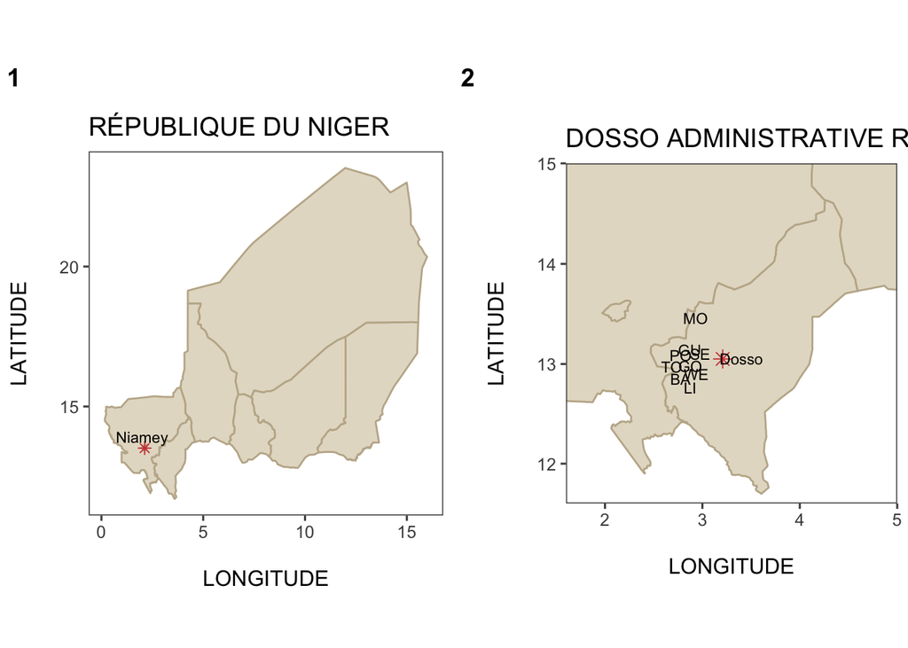

```r
nigerCountryGrid <- ggplot() +
  geom_polygon(data = nigerRegions,   # geom_polygon draw shape fill
               aes(x= long,     # longitude
                   y= lat,      # latitude
                   group = group),
               colour = "#C1B398",
               fill = "#E5DDCB") +
  theme_few() +
  coord_fixed(ratio = 1, xlim = NULL, ylim = NULL, expand = TRUE, clip = "on") +
  labs(title = "RÉPUBLIQUE DU NIGER",
       x = "\nLONGITUDE",
       y = "LATITUDE\n") +
  annotate("point", x = 2.1254, y = 13.5116, size = 2, colour = "#CF4647", shape = 8) + #Niamey
  annotate("text", x = 2, y = 13.9, label = "Niamey", size = 3) #Niamey
nigerDossoGrid <- ggplot() +
  geom_polygon(data = nigerRegions, #geom_polygon draw shape fill
               aes(x= long, #longitude
                   y= lat, #latitude
                   group = group),
               fill = "#E5DDCB",
               colour = "#C1B398") +
  theme_few() +
  labs(title = "DOSSO ADMINISTRATIVE REGION, NIGER",
       x = "\nLONGITUDE",
       y = "\nLATITUDE\n") +
  coord_fixed(ratio = 1, xlim = NULL, ylim = NULL, expand = TRUE, clip = "on") +
  coord_map(xlim = c(1.6, 5), ylim = c(11.6, 15)) +
  annotate("text", x = 2.775743, y = 12.851563, label = "BA", size = 3) + #BABA DEY
  annotate("text", x = 2.8755067, y = 12.9819084, label = "GO", size = 3) + #GOBERI PEULH
  annotate("text", x = 2.87, y = 13.14, label = "GU", size = 3) + #GUILLARE PEULH, COORDS ALTERED SLIGHTLY TO MAKE LABEL MORE CLEAR
  annotate("text", x = 2.8753615, y = 12.7657579, label = "LI", size = 3) + #LISSORE
  annotate("text", x = 2.9316658, y = 13.4575975, label = "MO", size = 3) + #MOUNBEINA FANDOGA
  annotate("text", x = 2.7768802, y = 13.0840501, label = "PO", size = 3) + #POULLO
  annotate("text", x = 2.9772676, y = 13.0993277, label = "SE", size = 3) + #SETTI I
  annotate("text", x = 2.6858407, y = 12.9739898, label = "TO", size = 3) + #TOMBO
  annotate("text", x = 2.9372924, y = 12.8960019, label = "WE", size = 3) + #WERE DJATAME PEUL
  annotate("point", x = 3.2081, y = 13.0505, size = 3, colour = "#CF4647", shape = 8) + #Dosso
  annotate("text", x = 3.4, y = 13.0505, label = "Dosso", size = 3) #Dosso
  #annotate("point", x = 2.1254, y = 13.5116, size = 3, colour = "#CF4647", shape = 8) #Niamey
  #annotate("text", x = 2, y = 13.9, label = "Niamey", size = 3) #Niamey

title <- ggdraw() + draw_label("", fontface = "bold")
mapGrid <- plot_grid(nigerCountryGrid, nigerDossoGrid, labels = c("1", "2"), nrow = 1, align = "h")
mapGrid <- plot_grid(title, mapGrid, ncol = 1, rel_heights = c(0.1, 1))
mapGrid
```

```r
#save_plot("map_grid_horizontal.jpg", mapGrid, base_height = 6, base_width = 18)
```

Inset country-level map in upper left-hand corner of region-level map.

```r
nigerCountryInset <- ggplot() +
  geom_polygon(data = nigerRegions,   # geom_polygon draw shape fill
               aes(x= long,     # longitude
                   y= lat,      # latitude
                   group = group),
               colour = "#C1B398",
               fill = "#E5DDCB") +
  theme_solid(fill = "white") +
  coord_fixed(ratio = 1, xlim = NULL, ylim = NULL, expand = TRUE, clip = "on") +
  labs(title = "",
       x = "",
       y = "") +
  annotate("point", x = 3.2081, y = 13.0505, size = 3, colour = "#CF4647", shape = 19) #Dosso
  #annotate("text", x = 3.4, y = 13.0505, label = "Dosso Region", size = 3) #Dosso

nigerDossoInset <- ggplot() +
  geom_polygon(data = nigerRegions, #geom_polygon draw shape fill
               aes(x= long, #longitude
                   y= lat, #latitude
                   group = group),
               fill = "#E5DDCB",
               colour = "#C1B398") +
  theme_few() +
  labs(title = "",
       x = "\nLONGITUDE",
       y = "LATITUDE\n") +
  coord_fixed(ratio = 1, xlim = NULL, ylim = NULL, expand = TRUE, clip = "on") +
  coord_map(xlim = c(1.6, 4.66), ylim = c(11.6, 14.66)) +
  annotate("point", x = 2.775743, y = 12.851563, shape = 16, color = "#CF4647") + #BABA DEY
  annotate("point", x = 2.8755067, y = 12.9819084, shape = 16, color = "#CF4647") + #GOBERI PEULH
  annotate("point", x = 2.8491551, y = 13.1197411, shape = 16, color = "#CF4647") + #GUILLARE PEULH
  annotate("point", x = 2.8753615, y = 12.7657579, shape = 16, color = "#CF4647") + #LISSORE
  annotate("point", x = 2.9316658, y = 13.4575975, shape = 16, color = "#CF4647") + #MOUNBEINA FANDOGA
  annotate("point", x = 2.7768802, y = 13.0840501, shape = 16, color = "#CF4647") + #POULLO
  annotate("point", x = 2.9772676, y = 13.0993277, shape = 16, color = "#CF4647") + #SETTI I
  annotate("point", x = 2.6858407, y = 12.9739898, shape = 16, color = "#CF4647") + #TOMBO
  annotate("point", x = 2.9372924, y = 12.8960019, shape = 16, color = "#CF4647") + #WERE DJATAME PEUL
  annotate("text", x = 2.55, y = 12.851563, label = "BA (14/18)", size = 3) +
  annotate("text", x = 3.05, y = 12.9819084, label = "GO (0/1)", size = 3) +
  annotate("text", x = 2.8491551, y = 13.2, label = "GU (13/18)", size = 3) +
  annotate("text", x = 2.8753615, y = 12.7, label = "LI (1/2)", size = 3) +
  annotate("text", x = 2.9316658, y = 13.525, label = "MO (14/16)", size = 3) +
  annotate("text", x = 2.58, y = 13.0840501, label = "PO (9/13)", size = 3) +
  annotate("text", x = 3.15, y = 13.0993277, label = "SE (3/9)", size = 3) +
  annotate("text", x = 2.52, y = 12.9739898, label = "TO (0/3)", size = 3) +
  annotate("text", x = 3.12, y = 12.8960019, label = "WE (3/4)", size = 3) +
  #annotate("point", x = 3.2081, y = 13.0505, size = 3, colour = "#CF4647", shape = 8) + #Dosso
  #annotate("text", x = 3.4, y = 13.0505, label = "Dosso", size = 3) #Dosso
  annotate("point", x = 2.1254, y = 13.5116, size = 3, colour = "#CF4647", shape = 8) + #Niamey
  annotate("text", x = 2.1254, y = 13.38, label = "Niamey", size = 3) #Niamey
#With inset.
png("niger_inset_map_percents.jpg", width = 6, height = 6, units = "in", res = 300)
png
```

[output not shown]

```r
grid.newpage()
vp1 <- viewport(width = 1, height = 1, x = 0.5, y = 0.5)  #the larger map
vp2 <- viewport(width = 0.325, height = 0.325, x = 0.325, y = 0.81)  #the inset in upper right
print(nigerDossoInset, vp = vp1)
print(nigerCountryInset, vp = vp2)
dev.off()
```

TEST: Play with labels.

```r
#FULL NAME LABELS
nigerDossoInset <- ggplot() +
  geom_polygon(data = nigerRegions, #geom_polygon draw shape fill
               aes(x= long, #longitude
                   y= lat, #latitude
                   group = group),
               fill = "#E5DDCB",
               colour = "#C1B398") +
  theme_few() +
  labs(title = "",
       x = "\nLongitude",
       y = "Latitude\n") +
  coord_fixed(ratio = 1, xlim = NULL, ylim = NULL, expand = TRUE, clip = "on") +
  coord_map(xlim = c(1.6, 4.66), ylim = c(11.6, 14.66)) +
  annotate("point", x = 2.775743, y = 12.851563, shape = 16, color = "#CF4647") + #BABA DEY
  annotate("point", x = 2.8755067, y = 12.9819084, shape = 16, color = "#CF4647") + #GOBERI PEULH
  annotate("point", x = 2.8491551, y = 13.1197411, shape = 16, color = "#CF4647") + #GUILLARE PEULH
  annotate("point", x = 2.8753615, y = 12.7657579, shape = 16, color = "#CF4647") + #LISSORE
  annotate("point", x = 2.9316658, y = 13.4575975, shape = 16, color = "#CF4647") + #MOUNBEINA FANDOGA
  annotate("point", x = 2.7768802, y = 13.0840501, shape = 16, color = "#CF4647") + #POULLO
  annotate("point", x = 2.9772676, y = 13.0993277, shape = 16, color = "#CF4647") + #SETTI I
  annotate("point", x = 2.6858407, y = 12.9739898, shape = 16, color = "#CF4647") + #TOMBO
  annotate("point", x = 2.9372924, y = 12.8960019, shape = 16, color = "#CF4647") + #WERE DJATAME PEUL
  annotate("text", x = 2.45, y = 12.851563, label = "Baba Dey (14/18)", size = 3) +
  annotate("text", x = 3.23, y = 12.9819084, label = "Goberi Peulh (0/1)", size = 3) +
  annotate("text", x = 2.8491551, y = 13.2, label = "Guillare Peulh (13/18)", size = 3) +
  annotate("text", x = 2.8753615, y = 12.7, label = "Lissore (1/2)", size = 3) +
  annotate("text", x = 2.9316658, y = 13.53, label = "Mounbeina Fandoga (14/16)", size = 3) +
  annotate("text", x = 2.52, y = 13.0840501, label = "Poullo (9/13)", size = 3) +
  annotate("text", x = 3.2, y = 13.0993277, label = "Setti I (3/9)", size = 3) +
  annotate("text", x = 2.45, y = 12.9739898, label = "Tombo (0/3)", size = 3) +
  annotate("text", x = 3.4, y = 12.8960019, label = "Were Djatame Peul (3/4)", size = 3) +
  #annotate("point", x = 3.2081, y = 13.0505, size = 3, colour = "#CF4647", shape = 8) + #Dosso
  #annotate("text", x = 3.4, y = 13.0505, label = "Dosso", size = 3) #Dosso
  annotate("point", x = 2.1254, y = 13.5116, size = 3, colour = "#CF4647", shape = 8) + #Niamey
  annotate("text", x = 2.1254, y = 13.38, label = "Niamey", size = 3) #Niamey
#PRINT.
png("niger_inset_map_fullname_ratio.jpg", width = 6, height = 6, units = "in", res = 300)
png
```

[output not shown]

```r
grid.newpage()
vp1 <- viewport(width = 1, height = 1, x = 0.5, y = 0.5)  #the larger map
vp2 <- viewport(width = 0.325, height = 0.325, x = 0.325, y = 0.81)  #the inset in upper right
print(nigerDossoInset, vp = vp1)
print(nigerCountryInset, vp = vp2)
dev.off()
```

TEST2: Play with labels.

```r
#PERCENT / INITIALS LABELS

nigerDossoInset <- ggplot() +
  geom_polygon(data = nigerRegions, #geom_polygon draw shape fill
               aes(x= long, #longitude
                   y= lat, #latitude
                   group = group),
               fill = "#E5DDCB",
               colour = "#C1B398") +
  theme_few() +
  labs(title = "",
       x = "\nLONGITUDE",
       y = "LATITUDE\n") +
  coord_fixed(ratio = 1, xlim = NULL, ylim = NULL, expand = TRUE, clip = "on") +
  coord_map(xlim = c(1.6, 4.66), ylim = c(11.6, 14.66)) +
  annotate("point", x = 2.775743, y = 12.851563, shape = 16, color = "#CF4647") + #BABA DEY
  annotate("point", x = 2.8755067, y = 12.9819084, shape = 16, color = "#CF4647") + #GOBERI PEULH
  annotate("point", x = 2.8491551, y = 13.1197411, shape = 16, color = "#CF4647") + #GUILLARE PEULH
  annotate("point", x = 2.8753615, y = 12.7657579, shape = 16, color = "#CF4647") + #LISSORE
  annotate("point", x = 2.9316658, y = 13.4575975, shape = 16, color = "#CF4647") + #MOUNBEINA FANDOGA
  annotate("point", x = 2.7768802, y = 13.0840501, shape = 16, color = "#CF4647") + #POULLO
  annotate("point", x = 2.9772676, y = 13.0993277, shape = 16, color = "#CF4647") + #SETTI I
  annotate("point", x = 2.6858407, y = 12.9739898, shape = 16, color = "#CF4647") + #TOMBO
  annotate("point", x = 2.9372924, y = 12.8960019, shape = 16, color = "#CF4647") + #WERE DJATAME PEUL
  annotate("text", x = 2.42, y = 12.851563, label = "BA (14/18, 77.8%)", size = 3) +
  annotate("text", x = 3.15, y = 12.9819084, label = "GO (0/1, 0%)", size = 3) +
  annotate("text", x = 2.8491551, y = 13.2, label = "GU (13/18, 72.2%)", size = 3) +
  annotate("text", x = 2.8753615, y = 12.7, label = "LI (1/2, 50.0%)", size = 3) +
  annotate("text", x = 2.9316658, y = 13.525, label = "MO (14/16, 87.5%)", size = 3) +
  annotate("text", x = 2.44, y = 13.0840501, label = "PO (9/13, 69.2%)", size = 3) +
  annotate("text", x = 3.29, y = 13.0993277, label = "SE (3/9, 33.3%)", size = 3) +
  annotate("text", x = 2.42, y = 12.9739898, label = "TO (0/3, 0%)", size = 3) +
  annotate("text", x = 3.26, y = 12.8960019, label = "WE (3/4, 75.0%)", size = 3) +
  #annotate("point", x = 3.2081, y = 13.0505, size = 3, colour = "#CF4647", shape = 8) + #Dosso
  #annotate("text", x = 3.4, y = 13.0505, label = "Dosso", size = 3) #Dosso
  annotate("point", x = 2.1254, y = 13.5116, size = 3, colour = "#CF4647", shape = 8) + #Niamey
  annotate("text", x = 2.1254, y = 13.38, label = "Niamey", size = 3) #Niamey
#PRINT.
png("niger_inset_map_initials_percents.jpg", width = 6, height = 6, units = "in", res = 300)
png
```

[output not shown]

```r
grid.newpage()
vp1 <- viewport(width = 1, height = 1, x = 0.5, y = 0.5)  #the larger map
vp2 <- viewport(width = 0.325, height = 0.325, x = 0.325, y = 0.81)  #the inset in upper right
print(nigerDossoInset, vp = vp1)
print(nigerCountryInset, vp = vp2)
dev.off()
```

TEST3: Play with labels.

```r
#FULL NAME LABELS
nigerDossoInset <- ggplot() +
  geom_polygon(data = nigerRegions, #geom_polygon draw shape fill
               aes(x= long, #longitude
                   y= lat, #latitude
                   group = group),
               fill = "#E5DDCB",
               colour = "#C1B398") +
  theme_few() +
  labs(title = "",
       x = "\nLongitude",
       y = "Latitude\n") +
  coord_fixed(ratio = 1, xlim = NULL, ylim = NULL, expand = TRUE, clip = "on") +
  coord_map(xlim = c(1.6, 4.66), ylim = c(11.6, 14.66)) +
  annotate("point", x = 2.775743, y = 12.851563, shape = 16, color = "#CF4647") + #BABA DEY
  annotate("point", x = 2.8755067, y = 12.9819084, shape = 16, color = "#CF4647") + #GOBERI PEULH
  annotate("point", x = 2.8491551, y = 13.1197411, shape = 16, color = "#CF4647") + #GUILLARE PEULH
  annotate("point", x = 2.8753615, y = 12.7657579, shape = 16, color = "#CF4647") + #LISSORE
  annotate("point", x = 2.9316658, y = 13.4575975, shape = 16, color = "#CF4647") + #MOUNBEINA FANDOGA
  annotate("point", x = 2.7768802, y = 13.0840501, shape = 16, color = "#CF4647") + #POULLO
  annotate("point", x = 2.9772676, y = 13.0993277, shape = 16, color = "#CF4647") + #SETTI I
  annotate("point", x = 2.6858407, y = 12.9739898, shape = 16, color = "#CF4647") + #TOMBO
  annotate("point", x = 2.9372924, y = 12.8960019, shape = 16, color = "#CF4647") + #WERE DJATAME PEU
  annotate("text", x = 2.3, y = 12.851563, label = "Baba Dey (14/18, 77.8%)", size = 3) +
  annotate("text", x = 3.31, y = 12.9819084, label = "Goberi Peulh (0/1, 0%)", size = 3) +
  annotate("text", x = 2.8491551, y = 13.25, label = "Guillare Peulh\n(13/18, 72.2%)", size = 3) +
  annotate("text", x = 2.8753615, y = 12.65, label = "Lissore\n(1/2, 50.0%)", size = 3) +
  annotate("text", x = 2.9316658, y = 13.58, label = "Mounbeina Fandoga\n(14/16, 87.5%)", size = 3) +
  annotate("text", x = 2.4, y = 13.0840501, label = "Poullo (9/13, 69.2%)", size = 3) +
  annotate("text", x = 3.34, y = 13.0993277, label = "Setti I (3/9, 33.3%)", size = 3) +
  annotate("text", x = 2.35, y = 12.9739898, label = "Tombo (0/3, 0%)", size = 3) +
  annotate("text", x = 3.53, y = 12.8960019, label = "Were Djatame Peul (3/4, 75.0%)", size = 3) +
  #annotate("point", x = 3.2081, y = 13.0505, size = 3, colour = "#CF4647", shape = 8) + #Dosso
  #annotate("text", x = 3.4, y = 13.0505, label = "Dosso", size = 3) #Dosso
  annotate("point", x = 2.1254, y = 13.5116, size = 3, colour = "#CF4647", shape = 8) + #Niamey
  annotate("text", x = 2.1254, y = 13.38, label = "Niamey", size = 3) #Niamey
#PRINT.
png("niger_inset_map_fullname_percents.jpg", width = 6, height = 6, units = "in", res = 300)
png
```

[output not shown]